# Sem-UBA

Introducción a la programación en R para el análisis de datos en ciencias sociales (con orientación al estudio de conflictos y movimientos sociales)

Segundo encuentro - Unidades de análisis, metodologías de investigación y programación de códigos en el estudio de los conflictos y los movimientos sociales

Dr. Agustín Santella (IIGG-UBA/CONICET)

Dr. Agustín Nieto (INHUS-CONICET/UNMdP)

12 de abril de 2024

[figure not shown]

# Unidades en el estudio de la acción colectiva

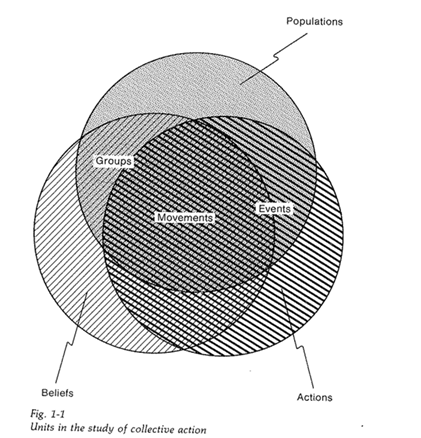

Tomado de Ch. Tilly, **From mobilization to revolution**, p. 10.

## Unidades en el estudio de la acción colectiva

**Población:** “queremos saber lo que pasó con los pobres en el Suffolk del siglo XVIII”.

**Creencias:** “ascenso y caída de las ideas del tratamiento justo de los pobres y los incompetentes”.

**Acciones:** “bajo que condiciones la gente común toma las leyes en sus propias manos”.

**Grupos:** “estructura común y creencias compartidas. Seguimos las acciones que resultan de la combinación de las estructuras y las creencias”.

**Movimientos:** “grupo de gente identificada mediante su compromiso a un conjunto de creencias”.

## Unidades en el estudio de la acción colectiva

“Las historias de la clase obrera generalmente toman esta forma: mucha atención en los cambios en las condiciones de vida, trabajo, y organización interna; llenas de materiales sobre creencias y perspectivas; análisis de las acciones que parecen expresar el carácter de la población de la clase obrera y sus creencias. También podemos tomar a los eventos como punto de partida…” (p. 9).

Esta distinción en el “punto de partida” o unidad de análisis se comparte en el debate marxista: clase o lucha. Véase el debate de E. P. Thompson contra el “estructuralismo marxista”: primero la lucha, luego la clase, o “lucha de clases sin clases”. También CICSO en Argentina en los 1970.

# Estudios sobre movimientos sociales en Latinoamérica

- “Methodological practices in social movements research”, Donatella della Porta editora, Oxford University Press, 2014, menciona pocas investigaciones de Latinoamérica.
- América Latina es referida 7 veces, contra 80 de Italia, 100 de Estados Unidos. Entre aquellas, Argentina y México 2 veces cada uno.
- 5 estudios regionales son citados según su autoría: J. Auyero 2003, T. Wada 2004, Collier y Collier 1991, Wickham-Crowley, M. Moyano.
- Los estados del arte locales destacan el trabajo de M. Svampa (Krausova, 2002; Somma, 2020), no obstante, tomaremos Auyero como expresión de un enfoque “cualitativo” y Wada de uno “cuantitativo”.
- Javier Auyero, Contentious Lives, 2003, usa la historias de vida, basado en etnografías, mientras que Takeshi Wada, Event Analysis of claim making in Mexico, 2004, usa el análisis de eventos de protesta, con fuente en periódicos.

# Unidades de análisis distintas en las investigaciones

- Auyero, Contentious Lives, ubica a las creencias, movimientos y las acciones en los eventos, como unidades de estudio.
- Wada, Event Analysis: eventos-acciones, creencias.
- ¿Y las poblaciones o los grupos?
- ¿Cómo se relacionan las unidades de análisis y variables en cada diseño de investigación?
- ¿Qué diseños para la construcción y análisis de los datos se pueden programar con R si Auyero o Wada quisieran usar el método computacional?

# Metodologías y aplicación de procedimientos en R

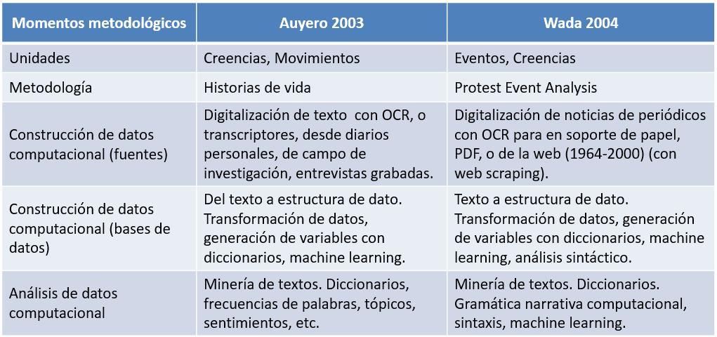

# Enfoques en el estudio de la conflictividad

- Bolsa de palabras o estructuras de la acción en los eventos (Protest Event Analysis).
- Bolsa de palabras: diccionario de conflictividad.
- Estructuras gramaticales.
- Codificación automática de la estructura de la acción mediante ML.

## **Enfoques gramaticales y computacionales de los eventos de protesta**

- *Análisis de eventos de protesta:* codificación a partir de las variables básicas y derivadas de la estructura sujeto-acción-objeto (SAO).
- Este tipo de construcción de la unidad de análisis se realiza mediante codificación manual.
- *Franzosi:* el PEA implicaba una estructura gramatical implícita.
- Análisis manual y computacional de las unidades SAO.
- El análisis sintáctico permite un procesamiento computacional pero se circunscribe a las unidades propias del texto (sentencias, palabras, párrafos). Problema: contextualizar en su unidad de conflicto a las acciones expresadas en las sentencias.
- ML permite la anotación (codificación) automática de los contextos sintéticos (párrafos).

# Sem-UBA

**Continuará…**

Dr. Agustín Santella (IIGG-UBA/CONICET)

Dr. Agustín Nieto (INHUS-CONICET/UNMdP)

12 de abril de 2024

[figure not shown]